# Functional programming in R

You’ll learn some of the powerful programming tools provided by `purrr`, one of the tidyverse core packages.

```r
library(tidyverse)
```

## Pipe operator

We are going to detour a bit to talk about pipe operator. Pipe operator is a powerful way to make your code much cleaner and readible by

- structuring sequences of data operations left-to-right (as opposed to from the inside and out),
- avoiding nested function calls,
- minimizing the need for local variables and function definitions, and
- making it easy to add steps anywhere in the sequence of operations.

The operators pipe their left-hand side values forward into expressions that appear on the right-hand side, i.e. one can replace `f(x)` with `x %>% f()`, where `%>%` is the (main) pipe-operator. When coupling several function calls with the pipe-operator, the benefit will become more apparent. Consider this pseudo example:

```r
raw_data <- read.csv("/path/to/data/file.csv")
sub_data <- subset(raw_data, variable_a > x)
new_data <- transform(sub_data, variable_c = variable_a / variable_b)
the_data <- head(new_data, 100)
```

However, the local variables are really not necessary, so one liner could be

```r
the_data <- head(
  transform(
    subset(
      read.csv("/path/to/data/file.csv"),
    variable_a > x),
  variable_c = variable_a / variable_b),
100)
```

But that is too hard to read and reason. If we use pipe operator,

```r
the_data <- read.csv("/path/to/data/file.csv") %>%
  subset(variable_a > x) %>%
  transform(variable_c = variable_a / variable_b) %>%
  head(100)
```

Hint: In RStudio, you could use `Ctrl + Shift + M` (or `Cmd + Shift + M`) to insert the pipe operator.

### Basic usage

- `x %>% f` or `x %>% f()` is equivalent to `f(x)`
- `x %>% f(y)` is equivalent to `f(x, y)`
- `x %>% f %>% g %>% h` is equivalent to `h(g(f(x)))`

```r
choose(5, 3)
```

```
## [1] 10
```

```r
5 %>% choose(3)
```

```
## [1] 10
```

### The argument placeholder

- `x %>% f(y, .)` is equivalent to `f(y, x)`
- `x %>% f(y, z = .)` is equivalent to `f(y, z = x)`

```r
3 %>% choose(5, .)
```

```
## [1] 10
```

```r
3 %>% choose(5, k = .)
```

```
## [1] 10
```

### Re-using the placeholder

It is straightforward to use the placeholder several times in a right-hand side expression. However, when the placeholder only appears in a nested expressions magrittr will still apply the first-argument rule. The reason is that in most cases this results more clean code.

`x %>% f(y = nrow(.), z = ncol(.))` is equivalent to `f(x, y = nrow(x), z = ncol(x))`

```r
5 %>% choose(. - 2)
```

```
## [1] 10
```

```r
5 %>% choose(3)
```

```
## [1] 10
```

```r
choose(5, 3)
```

```
## [1] 10
```

The behavior can be overruled by enclosing the right-hand side in braces:

`x %>% {f(y = nrow(.), z = ncol(.))}` is equivalent to `f(y = nrow(x), z = ncol(x))`

```r
list(n = 5, k = 3) %>% {choose(.$n, .$k)}
```

```
## [1] 10
```

## What is functional programming?

> In computer science, functional programming is a programming paradigm—a style of building the structure and elements of computer programs that treats computation as the evaluation of mathematical functions and avoids changing-state and mutable data.

To put is simple, it is a programming style without side effects.

```python
def f(x):
  x["a"] = 2
  return x

x = {"a": 1}
f(x) == x
```

```r
f <- function(x) {
  x$a <- 2
  x
}

x <- list(a = 1)
isTRUE(all.equal(f(x), x))
```

```
## [1] FALSE
```

## Is R a functional language?

R, at its heart, is a functional programming language. Most base R functions are pure, with a few notable exceptions:

- `library()` which loads a package, and hence modifies the search path.
- `setwd()`, `Sys.setenv()`, `Sys.setlocale()` which change the working directory, environment variables, and the locale, respectively.
- `plot()` and friends which produce graphical output.
- `write()`, `write.csv()`, `saveRDS()`, etc. which save output to disk.
- `options()` and `par()` which modify global settings.
- `S4` related functions which modify global tables of classes and methods.
- Random number generators which produce different numbers each time you run them

Almost everything else in R are functions.

```r
x <- 1
y <- 2
x + y
```

```
## [1] 3
```

```r
`+`(x, y)
```

```
## [1] 3
```

```r
a <- 3:5
a[3]
```

```
## [1] 5
```

```r
`[`(a, 3)
```

```
## [1] 5
```

```r
z <- 1
`<-`(z, 1)
```

## Revisit for loops

Suppose we want to compute the sample medians for each column of the data frame

```r
df <- tibble(
  a = rnorm(10),
  b = rnorm(10),
  c = rnorm(10),
  d = rnorm(10)
)
# if you want to be fancy
df <- tibble(!!!rerun(4, rnorm(10)) %>% set_names(letters[seq_len(length(.))]))
```

A naive way to do so

```r
median(df$a)
```

```
## [1] 0.01978186
```

```r
median(df$b)
```

```
## [1] 0.1187603
```

```r
median(df$c)
```

```
## [1] 0.5149308
```

```r
median(df$d)
```

```
## [1] -0.2765912
```

```r
# a base R for loop
output <- vector("double", ncol(df)) # 1. output
for (i in seq_along(df)) { # 2. sequence
  output[i] <- median(df[[i]]) # 3. body
}
output
```

```
## [1]  0.01978186  0.11876030  0.51493078 -0.27659118
```

### Base R solution

```r
lapply(df, median)
```

```
## $a
## [1] 0.01978186
##
## $b
## [1] 0.1187603
##
## $c
## [1] 0.5149308
##
## $d
## [1] -0.2765912
```

```r
sapply(df, median)
```

```
##           a           b           c           d
##  0.01978186  0.11876030  0.51493078 -0.27659118
```

These functions are great but they are not far less powerful then the next function `map`.

## Using `purrr`

THe `purrr` package (part of `tidyverse`) provides a function `map`.

The basic syntax for `map` is

```
map(ITERABLE, A_FUNCTION)
```

or

```
ITERABLE %>% map(A_FUNCTION)
```

- `ITERABLE`’s are objects like vectors, list and data frame.
- `A_FUNCTION` is a function, an expression, or a list of element names

```r
df %>% map(median)
```

```
## $a
## [1] 0.01978186
##
## $b
## [1] 0.1187603
##
## $c
## [1] 0.5149308
##
## $d
## [1] -0.2765912
```

Consider the following naive function which computes factorials

```r
fac <- function(n) {
  if (n == 1) {
    return(1L)
  } else {
    return(fac(n - 1L) * n)
  }
}
fac(5)
```

```
## [1] 120
```

Note that `fac` is not vectorized, it means that it doesn’t handle vector input.

```r
fac(1:5)
```

```
## [1] 1
```

```r
1:5 %>% map(fac)
```

```
## [[1]]
## [1] 1
##
## [[2]]
## [1] 2
##
## [[3]]
## [1] 6
##
## [[4]]
## [1] 24
##
## [[5]]
## [1] 120
```

is almost equivalent to `list(fac(1), fac(2), fac(3), fac(4), fac(5))`

### Passing additional arguments

```r
mean(..., trim = 0.5)
```

computes trimed mean of the input.

```r
df %>% map(mean, trim = 0.5)
```

```
## $a
## [1] 0.01978186
##
## $b
## [1] 0.1187603
##
## $c
## [1] 0.5149308
##
## $d
## [1] -0.2765912
```

### Inline function / expressions

```r
df %>% map(function(x) x^2)
```

```
## $a
##  [1] 0.0367944534 3.3908013505 0.4488066787 7.4371381571 0.1079089708
##  [6] 0.0006520353 0.0042378411 4.4398081984 0.3153364414 1.0791239456
##
## $b
##  [1] 2.113593895 2.767895414 0.035973420 5.790269592 0.103802998 0.002290005
##  [7] 1.130354983 2.012640797 0.596766374 0.841022259
##
## $c
##  [1] 0.57484657 0.14098998 1.07742210 0.01692514 6.43250376 0.03486967
##  [7] 0.93993706 0.42820693 3.03408402 0.39379314
##
## $d
##  [1] 0.049490274 0.066851222 1.766596767 0.156851587 0.002273364 0.138544741
##  [7] 0.086804675 1.264464778 3.156579878 1.734928663
```

or

```r
df %>% map(function(.) .^2)
```

```
## $a
##  [1] 0.0367944534 3.3908013505 0.4488066787 7.4371381571 0.1079089708
##  [6] 0.0006520353 0.0042378411 4.4398081984 0.3153364414 1.0791239456
##
## $b
##  [1] 2.113593895 2.767895414 0.035973420 5.790269592 0.103802998 0.002290005
##  [7] 1.130354983 2.012640797 0.596766374 0.841022259
##
## $c
##  [1] 0.57484657 0.14098998 1.07742210 0.01692514 6.43250376 0.03486967
##  [7] 0.93993706 0.42820693 3.03408402 0.39379314
##
## $d
##  [1] 0.049490274 0.066851222 1.766596767 0.156851587 0.002273364 0.138544741
##  [7] 0.086804675 1.264464778 3.156579878 1.734928663
```

or simply

```r
df %>% map(~ .^2)
```

```
## $a
##  [1] 0.0367944534 3.3908013505 0.4488066787 7.4371381571 0.1079089708
##  [6] 0.0006520353 0.0042378411 4.4398081984 0.3153364414 1.0791239456
##
## $b
##  [1] 2.113593895 2.767895414 0.035973420 5.790269592 0.103802998 0.002290005
##  [7] 1.130354983 2.012640797 0.596766374 0.841022259
##
## $c
##  [1] 0.57484657 0.14098998 1.07742210 0.01692514 6.43250376 0.03486967
##  [7] 0.93993706 0.42820693 3.03408402 0.39379314
##
## $d
##  [1] 0.049490274 0.066851222 1.766596767 0.156851587 0.002273364 0.138544741
##  [7] 0.086804675 1.264464778 3.156579878 1.734928663
```

### Name and position shortcuts

The `map` function also provide some shortcuts to extract elements from lists or vectors.

```r
# extract first elelment from each column
df %>% map(1)
```

```
## $a
## [1] 0.1918188
##
## $b
## [1] 1.45382
##
## $c
## [1] 0.7581864
##
## $d
## [1] -0.2224641
```

```r
roster <- list(
  list(name = "Peter", id = 1231, grades = list(STA141A = "A", STA141B = "A"), hobbies = c("Math", "Stat")),
  list(name = "Mary",  id = 4213, grades = list(STA141A = "B", STA141B = "B"), hobbies = c("Math", "Chem"))
)
```

```r
roster %>% map("name")
```

```
## [[1]]
## [1] "Peter"
##
## [[2]]
## [1] "Mary"
```

### Multi-level extraction

```r
roster %>% map(list("grades", "STA141B"))
```

```
## [[1]]
## [1] "A"
##
## [[2]]
## [1] "B"
```

```r
roster %>% map(list("hobbies", 1))
```

```
## [[1]]
## [1] "Math"
##
## [[2]]
## [1] "Math"
```

### Type-specific map

`map()` always returns a list, even if all the elements have the same flavor and are of length one. But in that case, you might prefer a simpler object.

- `map_lgl()` makes a logical vector.
- `map_int()` makes an integer vector.
- `map_dbl()` makes a double vector.
- `map_chr()` makes a character vector.

```r
df %>% map_dbl(mean)
```

```
##          a          b          c          d
## -0.2159470  0.2812730  0.2056805 -0.1241367
```

```r
1:5 %>% map_int(fac)
```

```
## [1]   1   2   6  24 120
```

```r
1:5 %>% map_lgl(~ . == 2L)
```

```
## [1] FALSE  TRUE FALSE FALSE FALSE
```

```r
roster %>% map_chr("name")
```

```
## [1] "Peter" "Mary"
```

### Enumerating over the input

`imap` enumerates over the input

```r
a <- c(11, 12, 13)
a %>% imap_dbl(function(v, i) v)
```

```
## [1] 11 12 13
```

```r
a %>% imap_dbl(function(v, i) i)
```

```
## [1] 1 2 3
```

```r
b <- c(4, 5, 6)
a %>% imap_dbl(function(v, i) v + b[i])
```

```
## [1] 15 17 19
```

```r
# equivalently
a %>% imap_dbl(~ .x + b[.y])
```

```
## [1] 15 17 19
```

### Extraction and assignment

```r
x <- 11:20
x %>% pluck(1) # equivalent to x[1]
```

```
## [1] 11
```

Nested extraction

```r
a_to_e <- list(lowers = letters[1:5], uppers = LETTERS[1:5])
a_to_e %>% pluck("lowers") # equivalent to a_to_e["lowers"]
```

```
## [1] "a" "b" "c" "d" "e"
```

```r
a_to_e %>% pluck("lowers", 2) # equivalent to a_to_e["lowers"][2]
```

```
## [1] "b"
```

Assignments

```r
a_to_e %>% assign_in(list("lowers", 2), "z")
```

```
## $lowers
## [1] "a" "z" "c" "d" "e"
##
## $uppers
## [1] "A" "B" "C" "D" "E"
```

```r
a_to_e %>% modify_in(list("lowers", 2), toupper)
```

```
## $lowers
## [1] "a" "B" "c" "d" "e"
##
## $uppers
## [1] "A" "B" "C" "D" "E"
```

These modifications are not in-place, the original variable is not modified

```r
a_to_e
```

```
## $lowers
## [1] "a" "b" "c" "d" "e"
##
## $uppers
## [1] "A" "B" "C" "D" "E"
```

### Keep and drop elements

```r
is_even <- function(x) x %% 2 == 0
11:20 %>% keep(is_even)
```

```
## [1] 12 14 16 18 20
```

```r
# or equivalently
11:20 %>% keep(~ . %% 2 == 0)
```

```
## [1] 12 14 16 18 20
```

```r
11:20 %>% keep(~ !is_even(.))
```

```
## [1] 11 13 15 17 19
```

```r
11:20 %>% keep(negate(is_even))
```

```
## [1] 11 13 15 17 19
```

```r
11:20 %>% discard(is_even)
```

```
## [1] 11 13 15 17 19
```

### Predicate functions

```r
# is every element in `eleven_to_twenty` even?
11:20 %>% every(is_even) # more efficient then all(is_even(11:20))
```

```
## [1] FALSE
```

```r
# are some elements in `eleven_to_twenty` even?
11:20 %>% some(is_even) # more efficient then any(is_even(11:20))
```

```
## [1] TRUE
```

```r
11:20 %>% has_element(12L)
```

```
## [1] TRUE
```

```r
# caution! 12 is a double, but 11:20 is a interger vector.
11:20 %>% has_element(12)
```

```
## [1] FALSE
```

```r
11:20 %>% some(~ . == 12)  # maybe a bit robust
```

```
## [1] TRUE
```

```r
# the first even number divisible by 7 is
11:20 %>% detect(~ . %% 7 == 0)
```

```
## [1] 14
```

```r
# get the index of the first element divisible by 7
11:20 %>% detect_index(~ . %% 7 == 0)
```

```
## [1] 4
```

### Map conditionaly

```r
square <- function(x) x^2
# square all even numbers
1:5 %>% map_if(is_even, square)
```

```
## [[1]]
## [1] 1
##
## [[2]]
## [1] 4
##
## [[3]]
## [1] 3
##
## [[4]]
## [1] 16
##
## [[5]]
## [1] 5
```

```r
# apply the function to the third and fifth positions
1:5 %>% map_at(c(3, 5), square)
```

```
## [[1]]
## [1] 1
##
## [[2]]
## [1] 2
##
## [[3]]
## [1] 9
##
## [[4]]
## [1] 4
##
## [[5]]
## [1] 25
```

Note: these are currently no type specific `map_if` or `map_at`.

### Modify elements selectively

Unlike `map()` and its variants which always return a fixed object type, the `modify()` family always returns the same type as the input object.

```r
x <- rnorm(5)
x %>% modify(square)
```

```
## [1] 0.58570787 0.01191177 7.54913897 1.65602525 0.32058206
```

```r
# it doesn't work because 1:5 is an integer vector, while `square` produces double
# 1:5 %>% modify(square)
as.double(1:5) %>% modify(square)
```

```
## [1]  1  4  9 16 25
```

```r
1:5 %>% modify(~ as.integer(.^2))
```

```
## [1]  1  4  9 16 25
```

```r
# make even numbers negative
1:5 %>% modify_if(is_even, ~ -.)
```

```
## [1]  1 -2  3 -4  5
```

```r
# make the third and fifth numbers negative
1:5 %>% modify_at(c(3, 5), ~ -.)
```

```
## [1]  1  2 -3  4 -5
```

Again, these modifications are not in-place.

### Reshape lists

```r
a_to_e <- list(lowers = letters[1:5], uppers = LETTERS[1:5])
# a_to_e %>% flatten()
a_to_e %>% flatten_chr()  # type specific
```

```
##  [1] "a" "b" "c" "d" "e" "A" "B" "C" "D" "E"
```

```r
a_to_e %>%
  transpose() %>%
  map(~ str_c(.$lowers, .$uppers))
```

```
## [[1]]
## [1] "aA"
##
## [[2]]
## [1] "bB"
##
## [[3]]
## [1] "cC"
##
## [[4]]
## [1] "dD"
##
## [[5]]
## [1] "eE"
```

```r
mpgt <- mpg %>% transpose()
mpgt[[5]]
```

```
## $manufacturer
## [1] "audi"
##
## $model
## [1] "a4"
##
## $displ
## [1] 2.8
##
## $year
## [1] 1999
##
## $cyl
## [1] 6
##
## $trans
## [1] "auto(l5)"
##
## $drv
## [1] "f"
##
## $cty
## [1] 16
##
## $hwy
## [1] 26
##
## $fl
## [1] "p"
##
## $class
## [1] "compact"
```

```r
(M <- matrix(1:9, nrow = 3, ncol = 3))
```

```
##      [,1] [,2] [,3]
## [1,]    1    4    7
## [2,]    2    5    8
## [3,]    3    6    9
```

```r
# base R
apply(M, 1, mean)  # it is not a perfect example because there is rowMeans(M)
```

```
## [1] 4 5 6
```

```r
# tidyverse version
M %>% array_tree(1) %>% map_dbl(mean)
```

```
## [1] 4 5 6
```

### Add elements to lists

```r
li <- list(a = 1, b = 2)
li %>%
  append(list(c = 3, d = 3)) %>%
  prepend(list(x = 0, y = 0)) %>%
  splice(u = 3, v = 4)
```

```
## $x
## [1] 0
##
## $y
## [1] 0
##
## $a
## [1] 1
##
## $b
## [1] 2
##
## $c
## [1] 3
##
## $d
## [1] 3
##
## $u
## [1] 3
##
## $v
## [1] 4
```

### Capture errors and warnings

```r
log("a")  # gives error
```

```
## Error in log("a"): non-numeric argument to mathematical function
```

```r
log(-1)   # gives warning
```

```
## Warning in log(-1): NaNs produced
```

```
## [1] NaN
```

```r
list("a", -1, 3) %>% map(log)
```

```
## Error in .Primitive("log")(x, base): non-numeric argument to mathematical function
```

```r
list("a", -1, 3) %>%
  map(safely(log))
```

```
## [[1]]
## [[1]]$result
## NULL
##
## [[1]]$error
## <simpleError in .Primitive("log")(x, base): non-numeric argument to mathematical function>
##
##
## [[2]]
## [[2]]$result
## [1] NaN
##
## [[2]]$error
## NULL
##
##
## [[3]]
## [[3]]$result
## [1] 1.098612
##
## [[3]]$error
## NULL
```

```r
list(-1, 3) %>%
  map(quietly(log)) %>%
  map_dbl("result")
```

```
## [1]      NaN 1.098612
```

```r
list("a", 3) %>%
  map_dbl(possibly(log, NaN))
```

```
## [1]      NaN 1.098612
```

### Map more than one argument

Two arguments

```r
a <- c(7, 8, 9)
b <- c(2, 3, 4)

map2(a, b, choose)
```

```
## [[1]]
## [1] 21
##
## [[2]]
## [1] 56
##
## [[3]]
## [1] 126
```

```r
a %>% map2(b, choose)
```

```
## [[1]]
## [1] 21
##
## [[2]]
## [1] 56
##
## [[3]]
## [1] 126
```

```r
b %>% map2(a, ., choose)
```

```
## [[1]]
## [1] 21
##
## [[2]]
## [1] 56
##
## [[3]]
## [1] 126
```

```r
# or equivalently
map2(a, b, function(x, y) choose(x, y))
```

```
## [[1]]
## [1] 21
##
## [[2]]
## [1] 56
##
## [[3]]
## [1] 126
```

```r
map2(a, b, ~ choose(.x, .y))
```

```
## [[1]]
## [1] 21
##
## [[2]]
## [1] 56
##
## [[3]]
## [1] 126
```

More than two arguments

```r
x <- list(
  a = c(1, 2, 3),
  b = c(5, 4, 8),
  c = c(4, 7, 9)
)

x %>% pmap(function(a, b, c) a / (b + c))
```

```
## [[1]]
## [1] 0.1111111
##
## [[2]]
## [1] 0.1818182
##
## [[3]]
## [1] 0.1764706
```

### Cross

The `map` function applies to the inputs elementwisely. Sometimes, we wish to consider all combinations of the inputs. The `cross*` functions are designed to handle those situations.

`cross2` expects two iterables and usually is used together with `lift`

```r
a <- c(7, 8, 9)
b <- c(2, 3, 4)

cross2(a, b) %>% map_dbl(lift(choose))
```

```
## [1]  21  28  36  35  56  84  35  70 126
```

`cross` expects a list of iterables

```r
li <- list(
  a = c(7, 8, 9),
  b = c(2, 3, 4)
)
li %>%
  set_names(c("n", "k")) %>%
  cross() %>%
  map(lift(choose))
```

```
## [[1]]
## [1] 21
##
## [[2]]
## [1] 28
##
## [[3]]
## [1] 36
##
## [[4]]
## [1] 35
##
## [[5]]
## [1] 56
##
## [[6]]
## [1] 84
##
## [[7]]
## [1] 35
##
## [[8]]
## [1] 70
##
## [[9]]
## [1] 126
```

```r
dat <- tibble(
  x = seq(-1, 1, length = 10),
  y = seq(-1, 1, length = 10)
)
dat
```

```
## # A tibble: 10 x 2
##         x      y
##     <dbl>  <dbl>
##  1 -1     -1
##  2 -0.778 -0.778
##  3 -0.556 -0.556
##  4 -0.333 -0.333
##  5 -0.111 -0.111
##  6  0.111  0.111
##  7  0.333  0.333
##  8  0.556  0.556
##  9  0.778  0.778
## 10  1      1
```

We wish to plot a heat map of `sqrt(x^2 + y^2)`

```r
dat %>% mutate(z  = sqrt(x^2 + y^2)) # wrong
```

```
## # A tibble: 10 x 3
##         x      y     z
##     <dbl>  <dbl> <dbl>
##  1 -1     -1     1.41
##  2 -0.778 -0.778 1.10
##  3 -0.556 -0.556 0.786
##  4 -0.333 -0.333 0.471
##  5 -0.111 -0.111 0.157
##  6  0.111  0.111 0.157
##  7  0.333  0.333 0.471
##  8  0.556  0.556 0.786
##  9  0.778  0.778 1.10
## 10  1      1     1.41
```

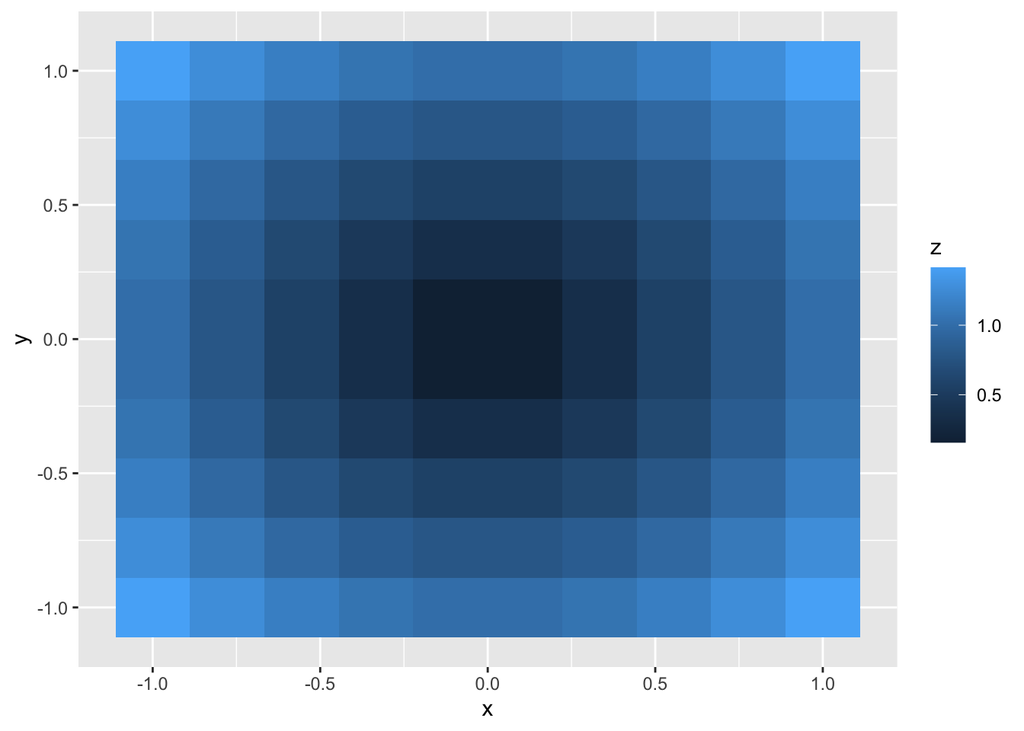

```r
dat %>%
  cross_df() %>%
  mutate(z = sqrt(x^2 + y^2)) %>%
  ggplot(aes(x, y, fill = z)) +
  geom_tile()
```

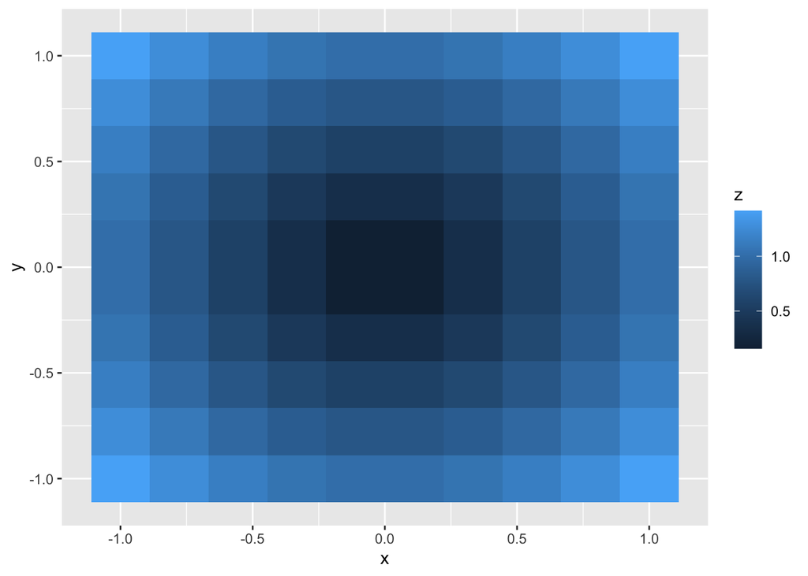

```r
# alternatively
dat %>%
  expand(x, y) %>%
  mutate(z = sqrt(x^2 + y^2)) %>%
  ggplot(aes(x, y, fill = z)) +
  geom_tile()
```

The difference is that `cross_df` doesn’t handle duplications.

```r
dat <- tibble(
  x = c(1, 1),
  y = c(2, 3)
)
dat %>% cross_df()
```

```
## # A tibble: 4 x 2
##       x     y
##   <dbl> <dbl>
## 1     1     2
## 2     1     2
## 3     1     3
## 4     1     3
```

```r
dat %>% expand(x, y)
```

```
## # A tibble: 2 x 2
##       x     y
##   <dbl> <dbl>
## 1     1     2
## 2     1     3
```

### Reduce iterable

The `reduce` function combines the values of a vector by iteratively applying a binary function.

```r
x <- 1:4
x %>% reduce(`+`)
```

```
## [1] 10
```

```r
# it means ((1 + 2) + 3) + 4
1:4 %>% reduce(`+`, .dir = "backward")
```

```
## [1] 10
```

```r
# it means 1 + (2 + (3 + 4))
```

It is usefully if we want to average data frames / matrices.

```r
matrices <- list(
  matrix(rnorm(9), nr = 3, nc = 3),
  matrix(rnorm(9), nr = 3, nc = 3),
  matrix(rnorm(9), nr = 3, nc = 3)
)
matrices %>% reduce(`+`) %>% `/`(length(.))
```

```
##            [,1]        [,2]       [,3]
## [1,]  0.2824591 -0.29669106  0.1038984
## [2,] -0.3477254  0.09619005  0.1406002
## [3,]  0.1536736 -0.14978600 -0.3014066
```

It is also useful if we wants to row bind。

```r
ll <- list(
  c(name = "Peter", age = 23),
  c(name = "Paul", age = 19),
  c(name = "Mary", age = 22)
)
```

```r
bind_rows(ll)  #  it only works in dplyr 1.0
```

```
## # A tibble: 3 x 2
##   name  age
## * <chr> <chr>
## 1 Peter 23
## 2 Paul  19
## 3 Mary  22
```

```r
ll %>% reduce(bind_rows)
```

```
## # A tibble: 3 x 2
##   name  age
## * <chr> <chr>
## 1 Peter 23
## 2 Paul  19
## 3 Mary  22
```

## A example of linear regression

```r
mtcars %>%
  nest(data = -cyl) %>%
  mutate(model = map(data, ~ lm(mpg ~ wt, data = .))) %>%
  transmute(r_sq = model %>% map(summary) %>% map_dbl("r.squared"))
```

```
## # A tibble: 3 x 1
##    r_sq
##   <dbl>
## 1 0.465
## 2 0.509
## 3 0.423
```

```r
# it is more readible
mtcars %>%
  group_by(cyl) %>%
  nest() %>%
  mutate(model = map(data, ~ lm(mpg ~ wt, data = .))) %>%
  transmute(r_sq = model %>% map(summary) %>% map_dbl("r.squared"))
```

```
## # A tibble: 3 x 2
## # Groups:   cyl [3]
##     cyl  r_sq
##   <dbl> <dbl>
## 1     6 0.465
## 2     4 0.509
## 3     8 0.423
```

## Related concepts of R Functions

### Lexical scoping

```r
y <- 2
addy <- function(x) {
  x + y
}
addy(3)
```

```
## [1] 5
```

```r
foo <- function(x) {
  addy(x)
}
foo(3)
```

```
## [1] 5
```

The look up is dynamic though,

```r
y <- 4
addy(3)
```

```
## [1] 7
```

### Dynamic scoping

```r
y <- 2
addy <- function(x) {
  x + y
}

bar <- function(x) {
  y <- 4
  addy(x)
}
bar(3)
```

```
## [1] 5
```

```r
bar <- function(x) {
  y <- 4
  environment(addy) <- environment()
  addy(x)
}
bar(3)
```

```
## [1] 7
```

### Lazy evaluation

In R, an expression is only evaluted when it is needed.

```r
one <- function() {
  cat("called one\n")
  1
}

square <- function(x) {
  cat("called square\n")
  x^2
}
square(one())
```

```
## called square
## called one
```

```
## [1] 1
```

For comparsion, python is eager.

```python
def one():
  print("called one")
  return 1

def square(x):
  print("call square")
  return x**2

square(one())
```

```
## called one
## call square
## 1
```

R could do a lot of interesting things with lazy evaluation.

```r
echo <- function(x) {
  cat("you typed\n")
  print(substitute(x))
}

echo(it + does - not == have * to / make ^ sense)
```

```
## you typed
## it + does - not == have * to/make^sense
```

### Some terminology

We end this chapter with several terminology.

- functionals
  - functions that have function inputs. For example, `map`: `map(x, mean)`.
- function factories
  - functions that return functions, For example,

    ```r
    pow <- function(k) {
      force(k)  # to avoid lazy evaluation
      function(x) {
        x^k
      }
    }
    square <- pow(2)
    square(5)
    ```

    ```
    ## [1] 25
    ```

- function operators
  - function that has function input(s) and returns a function. For examples, `lift`, `safely`.

# References

- R for Data Science https://r4ds.had.co.nz/iteration.html
- Advanced R https://adv-r.hadley.nz/fp.html
- purrr tutorial https://jennybc.github.io/purrr-tutorial/
- purrr cheatsheet https://github.com/rstudio/cheatsheets/blob/master/purrr.pdf